# Mental Models: Regression & Correlation

Bernard Ade

Correlation implies the strength of relationship between two or more variables. Learners of correlation are often cautioned that “correlation does not imply causation”. On the other hand, regression suggests a causal relationship between one or more independent variables and one dependent variable, also reffered to as response variable. The purpose of regression is to make predictions.

In this [video](https://www.youtube.com/watch?v=Y8Shin0iqQI), Prof. Patrick Meyer illustrates how to conduct correlation and regression by hand. My notes below borrows from his simple and lucid example. I will demonstrate how to replicate the same problem using R’s flexible methods that accomplishes the same task within a few lines of code. In addition, I will solve the problem using the formula below as illustrated in the video by hand.

$cov_{x,y}=\frac{\sum_{i=1}^{N}(x_{i}-\bar{x})(y_{i}-\bar{y})}{N-1}$

### Marathon Times

The number of training miles is believed to be related to the amount of time needed to finish a marathon. To test this hypothesis, a researcher collects weekly logs on eight on runners and he also records their marathon finish time. From the training logs, he computes the number of kilometers ran per week(KM/week) for each runner and the participant’s marathon finish time (in minutes)

#### Loading libraries

```r
library(tidyverse)
library(plotly)
```

#### Here is the data for the problem including 2 variables, kilometer per week and minutes

```r
marathon = tibble(
  km_week = c(51, 68, 86, 50, 84, 70, 90, 40),
  minutes = c(216, 179, 195, 196, 190, 201, 199, 203))
marathon
```

| km_week | minutes |
| --- | --- |
| 51 | 216 |
| 68 | 179 |
| 86 | 195 |
| 50 | 196 |
| 84 | 190 |
| 70 | 201 |
| 90 | 199 |
| 40 | 203 |

#### Scatterplot of the data to form an impression

```r
p = plot_ly(marathon, x = ~minutes, y = ~km_week, type ="scatter", mode = "markers")
p
```

[interactive chart not shown]

#### Build linear model.

```r
model = lm(minutes ~ km_week, data = marathon)
```

```r
library(broom) # tidy our summary of linear model
tidy(model)
```

| term | estimate | std.error | statistic | p.value |
| --- | --- | --- | --- | --- |
| (Intercept) | 212.895710 | 14.7525021 | 14.431159 | 0.000006935929 |
| km_week | -0.230363 | 0.2118964 | -1.087149 | 0.318703080214 |

### Results

Lets compare Prof. Patrick Meyer’s hand calculation with the summary of our linear model. The estimate of -0.2304 indicates that as we increase weekly mileage by 1km, the runners marathon time decrease by .23 minutes.

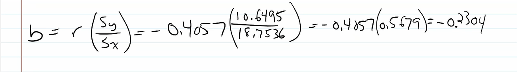

### Compute using formula.

Using the Professors video notes as a guide, below is the code version to build intuition.

$cov_{x,y}=\frac{\sum_{i=1}^{N}(x_{i}-\bar{x})(y_{i}-\bar{y})}{N-1}$

Compute deviation scores for kilometer per week and minutes

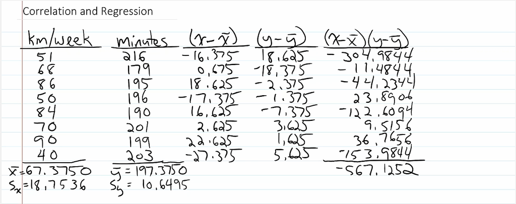

```r
marathon =
  marathon %>%
  mutate(deviation_scores_km_week = km_week - mean(km_week),
         deviation_scores_minutes = minutes - mean(minutes),
         mul_dev_scores = deviation_scores_km_week * deviation_scores_minutes)
marathon
```

| km_week | minutes | deviation_scores_km_week | deviation_scores_minutes | mul_dev_scores |
| --- | --- | --- | --- | --- |
| 51 | 216 | -16.375 | 18.625 | -304.984375 |
| 68 | 179 | 0.625 | -18.375 | -11.484375 |
| 86 | 195 | 18.625 | -2.375 | -44.234375 |
| 50 | 196 | -17.375 | -1.375 | 23.890625 |
| 84 | 190 | 16.625 | -7.375 | -122.609375 |
| 70 | 201 | 2.625 | 3.625 | 9.515625 |
| 90 | 199 | 22.625 | 1.625 | 36.765625 |
| 40 | 203 | -27.375 | 5.625 | -153.984375 |

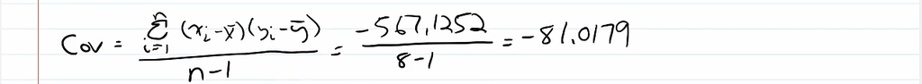

#### Covariance

```r
n = 8
cov = sum((marathon$deviation_scores_km_week) * (marathon$deviation_scores_minutes)) / (n-1)
cov
```

```
[1] -81.01786
```

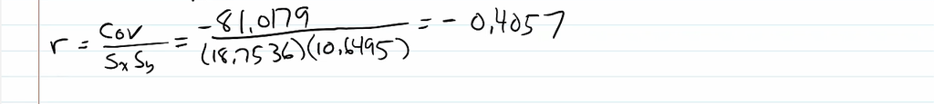

#### Correlation

```r
r = cov/(sd(marathon$km_week)*sd(marathon$minutes))
r
```

```
[1] -0.405667
```

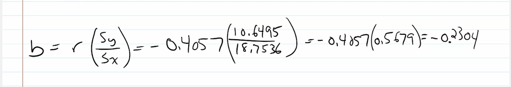

#### Equation for slope

```r
b = r*(sd(marathon$minutes)/sd(marathon$km_week))
b
```

```
[1] -0.230363
```

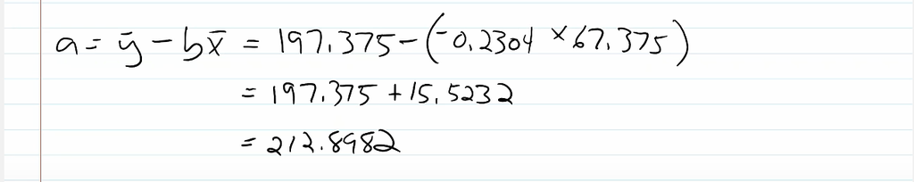

#### Equation for Intercept

```r
a = mean(marathon$minutes) - b*mean(marathon$km_week)
a
```

```
[1] 212.8957
```

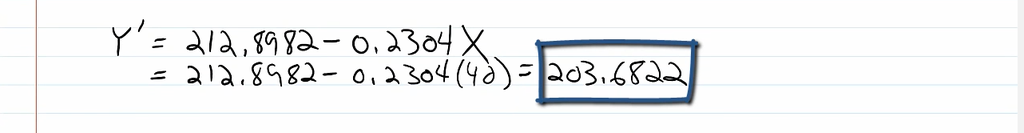

#### Predict a score using the value of x.

```r
x = 40
y_predicted = a - (-b*x)
y_predicted
```

```
[1] 203.6812
```